# Обработка и распознавание изображений

## Отчет по лабораторной работе №1

### 1. Постановка задачи

Целью данной лабораторной работы является разработать и реализовать программу для работы с изображений фишек игрового набора Тантрикс, обеспечивающую:  
• Ввод и отображение на экране изображений в формате BMP;  
• Сегментацию изображений на основе точечных и пространственных преобразований;  
• Генерацию признаковых описаний фишек на изображении;  
• Классификацию отдельных фишек и их последовательностей.  
Была выбрана задача класса Intermediate:  
1) Необходимо определить номер фишки. Вход – файл типа Single*.bmp.  
2) Определить расположение и номера всех фишек в кадре. Вход – файл типа Group*.bmp.

### 3. Описания метода решения, программной реализации и проведенных экспериментов для осуществления реализации программы

**1) Определение расположения фишек в кадре**  
Для начала необходимо выделить контуры, соответствующие шестиугольникам.  
Для того чтобы сделать это, выполняем бинаризацию изображения по адаптивному гауссовскому пороговому значению. Размеры области окрестности, для которой считался порог, подбирался эмпирически. Перед этим действием и после него применяется медианный фильтр для избавления от шума.

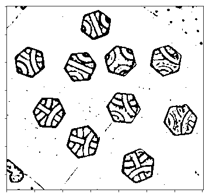

```python
image_col=cv2.imread("samples\Group_4.bmp")
image=cv2.imread("samples\Group_4.bmp",0)
img=image.copy()
bin_img = cv2.medianBlur(img, 5)
bin_img = cv2.adaptiveThreshold(bin_img, 255, cv2.ADAPTIVE_THRESH_GAUSSIAN_C, cv2.THRESH_BINARY, 19, 2)
bin_img = cv2.medianBlur(bin_img, 5)
plot_image(bin_img,1)
```

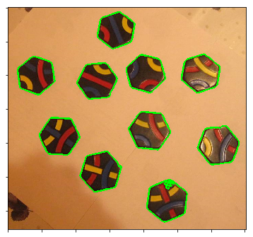

```python
contours1=cv2.findContours(bin_img, cv2.RETR_TREE, cv2.CHAIN_APPROX_SIMPLE)[1]
external = cv2.findContours(bin_img, cv2.RETR_EXTERNAL, cv2.CHAIN_APPROX_SIMPLE)[1]
max_ext_area =np.max([cv2.contourArea(x) for x in external])

areas=[]
for x in contours1:
    area=cv2.contourArea(x)
    if area<max_ext_area:
        areas.append(area)

max_inner_area =np.max(areas)

conv_list1=[]
hex_list=[]
contours=[]
for x in contours1:
    area=cv2.contourArea(x)
    if 0.5*max_inner_area<area<max_ext_area:
        contours.append(x)
        hexagon = cv2.convexHull(x)
        conv_list1.append(hexagon)
        epsilon = 0.05*(0.5*max_inner_area)/area * cv2.arcLength(hexagon, True)
        hexagon = cv2.approxPolyDP(hexagon, epsilon, True)
        if len(hexagon)==6:
            hex_list.append(hexagon)

plot_image(cv2.drawContours(image_col.copy(), contours, -1, (0,255,0), 3),1)
```

Берем только те многоугольники, у которых число сторон равно 6.

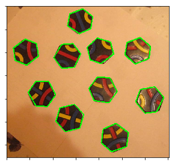

```python
plot_image(cv2.drawContours(image_col.copy(), hex_list, -1, (0,255,0), 3),0.8)
```

**2) Извлечение признаков у фишек**  
Необходимо построить функции фильтров для красного, желтого и синиго цветов.  
Для синего и красного цвета диапозоны в BGR настраиваем вручную. Для увеличения количества признаков и повышения точности построим еще один фильтр для синего цвета: берем синюю компоненту в пространстве цветов BGR и применяем пороговую бинаризуию. Для желтого цвета берем зеленую компоненту в BGR и применяем пороговую бинаризуию.

```python
def red_filter(img):
    lower = np.array([0, 0, 90])
    upper = np.array([65, 50, 255])
    mask = cv2.inRange(img, lower, upper)
    return mask

def yellow_filter(img):
    img = cv2.split(img)[1]
    img = cv2.medianBlur(img,5)
    mask = cv2.threshold(img, 110, 255, cv2.THRESH_BINARY)[1]
    return mask

def blue_filter(img):
    lower = np.array([39, 40, 41])
    upper = np.array([125, 140, 150])
    mask = cv2.inRange(img, lower, upper)
    return mask

def blue_filter2(img):
    img = cv2.split(img)[0]
    img = cv2.medianBlur(img,5)
    mask = np.array(cv2.threshold(img, 50, 255, cv2.THRESH_BINARY)[1])
    return mask
```

Результаты работы масок:

```
при применении фильтра для красного цвета
```

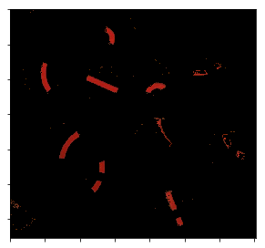

```
при применении фильтра для синего цвета
```

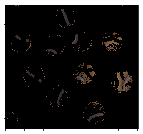

```
при применении еще одного фильтра для синего цвета
```

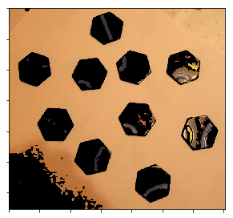

```
при применении фильтра для желтого цвета
```

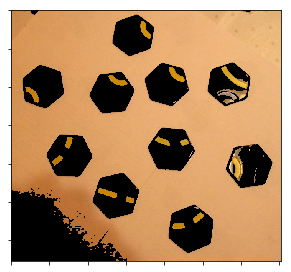

```python
print("при применении фильтра для красного цвета")
plot_image(cv2.bitwise_and(image_col.copy(), image_col.copy(), mask=red_filter(image_col.copy())),0.8)
print("при применении фильтра для синего цвета")
plot_image(cv2.bitwise_and(image_col.copy(), image_col.copy(), mask=blue_filter(image_col.copy())),0.8)
print("при применении еще одного фильтра для синего цвета")
plot_image(cv2.bitwise_and(image_col.copy(), image_col.copy(), mask=blue_filter2(image_col.copy())),0.8)
print("при применении фильтра для желтого цвета")
plot_image(cv2.bitwise_and(image_col.copy(), image_col.copy(), mask=yellow_filter(image_col.copy())),0.8)
```

Сегменты цветных линий соединяют середины сторон шестиугольников. Заметим, что фишка полностью идентифицируется порядком следования цветов на грани шестиугольника по часовой стрелке с точностью до циклического сдвига. Поэтому строим маски полуокружностей с центром в середине стороны фигуры и радиусом, равным третьей части этой стороны. Затем совмещаем маски цветов и полуокружностей и получаем область линии каждого цвета в полуокружностях.

```python
mask_all = np.zeros(image.shape)
red_all = red_filter(image_col.copy())
blue_all = blue_filter(image_col.copy())
blue2_all = blue_filter2(image_col.copy())
yellow_all = yellow_filter(image_col.copy())
for hexagon in hex_list:
    for lin in range(6):
        red = red_filter(image_col.copy())
        blue = blue_filter(image_col.copy())
        blue2 = blue_filter2(image_col.copy())
        yellow = yellow_filter(image_col.copy())
        #Координаты x, y  точек начала и конца всех сторон шестиугольника
        x1 = hexagon[lin % 6][0][0]
        x2 = hexagon[(lin+1)%6][0][0]
        y2 = hexagon[(lin+1)%6][0][1]
        y1 = hexagon[lin%6][0][1]
        #угол наклона стороны шестиугольника относительно оси x
        rads = math.atan2(y2 - y1, x2 - x1)
        if rads < 0:
            rads = rads + 2 * math.pi
        degs = math.degrees(rads)
        # Координаты середины стороны шестиугольника
        center = (int((x1+x2)/2),int((y1+y2)/2))
        # Длина стороны шшестиугольника
        length = int(math.sqrt((x1-x2)**2 + (y1-y2)**2))
        mask = np.zeros(image.shape)
        #Маска в виде полуокружности с центром в center и радиусом треть длины стороны шестиугольника
        cv2.ellipse(mask, center, (length//3, length//3), degs, 0, 180, 255, -1)
        cv2.ellipse(mask_all, center, (length//3, length//3), degs, 0, 180, 255, -1)
        red[mask==0] = 0
        blue[mask == 0] = 0
        blue2[mask == 0] = 0
        yellow[mask == 0] = 0
```

```
Маски полуокружностей
```

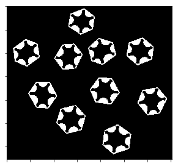

```
Область красной линии в полуокружностиях
```

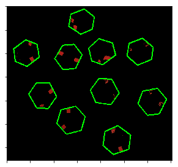

```
Область синей линии в полуокружностях (1 фильтр)
```

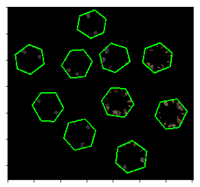

```
Область синей линии в  полуокружностях (2 фильтр)
```

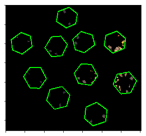

```
Область желтой линии в  полуокружностях
```

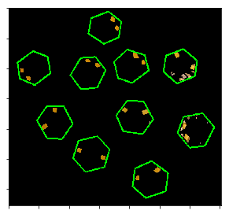

```python
red_all[mask_all==0] = 0
blue_all[mask_all == 0] = 0
blue2_all[mask_all == 0] = 0
yellow_all[mask_all == 0] = 0
img_red=cv2.bitwise_and(image_col.copy(), image_col.copy(), mask=red_all)
img_blue=cv2.bitwise_and(image_col.copy(), image_col.copy(), mask=blue_all)
img_blue2=cv2.bitwise_and(image_col.copy(), image_col.copy(), mask=blue2_all)
img_yellow=cv2.bitwise_and(image_col.copy(), image_col.copy(), mask=yellow_all)
print("Маски полуокружностей")
plot_image(cv2.drawContours(mask_all.copy(), hex_list, -1, (255,255,255), 3),0.8)
print("Область красной линии в полуокружностиях")
plot_image(cv2.drawContours(img_red.copy(), hex_list, -1, (0,255,0), 3),0.8)
print("Область синей линии в полуокружностях (1 фильтр)")
plot_image(cv2.drawContours(img_blue.copy(), hex_list, -1, (0,255,0), 3),0.8)
print("Область синей линии в  полуокружностях (2 фильтр)")
plot_image(cv2.drawContours(img_blue2.copy(), hex_list, -1, (0,255,0), 3),0.8)
print("Область желтой линии в  полуокружностях")
plot_image(cv2.drawContours(img_yellow.copy(), hex_list, -1, (0,255,0), 3),0.8)
```

В качестве признаков шестиугольника можно взять доли площадей, занятых каждым из цветов в полуокружностях. На полученных признаках обучить логистическую регрессию, градиентный бустинг, knn, svm. Номер фишки будет определяться последовательностью цветов на грани шестиугольника с точностью до циклического сдвига. По очереди каждый классификатор предсказывает нужную последовательность цветов, если она корректна, то написать на фишке соответствующий номер.

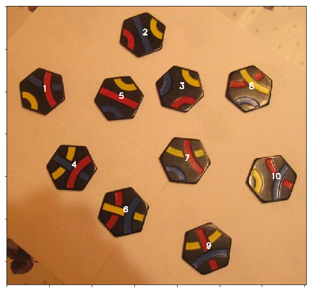

```python
image_0, image_1=read("Group_4.bmp")
solution("group_results",False,image_0,image_1,[clf1,clf2,clf3,clf4])
```

### 4. Выводы

В данной лабораторной работе нам пришлось решить такие задачи: локализация геометрических фигур; идентификация типов фишек. Для локализации геометрических фигур мы воспользовались бинаризацией по адаптивному порогу, построением выпуклой оболочки замкнутых контуров и аппроксимацией ее в многоугольник. В этой лабораторной работе мы столкнулись с тем, что рельеф фигур и посторонние текстуры давали дополнительные контуры. Нахождение площадей замкнутых фигур и выбор замкнутых контуров, площадь которых находилась в корректных границах, помогла справиться с этой трудностью. В борьбе с шумом хорошо себя показали медианный фильтр. Для идентификации объектов мы воспользовались построением цветных масок-полуокружностей, прилегающих к граням шестиугольников. Для классификации цвета потребовалось найти долю площади, занятую каждым цветом в полуокружности. Классификаторы цветов для каждой стороны шестиугольника обучались с помощью методов машинного обучения. Объект идентифицировался соответствующей ему последовательностью цветов.